# eFP-Seq Browser

*A. thaliana* eFP-Seq Browser

Priyank Purohit, Dr. Nicholas Provart. University of Toronto.

[figure not shown]

*Locus*

e.g. AT2G24270

*RNA-Seq Y-axis Scale*

'Auto' or >= 1

Absolute Relative

Based on RPKM values

Log2 of RPKM to average  
controls RPKM ratio

*SVG Colouring Mode*

*eFP Absolute Max Value*

Automatically set to  
highest value

Recolour

Title

RNA-Seq Coverage

PCC

eFP (RPKM)

RPKM

Details

[figure not shown]

Aerial part of long-day-grown 4-leaf-stage seedling with mock (NaCl) treatment

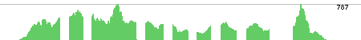

[figure not shown]

0.56796

rosettePlusRoot

93.16042

E-MTAB-1668:24hCS-RNA  
[NCBI SRA](http://www.ncbi.nlm.nih.gov/Traces/sra/?run=ERR274310); [PubLink](http://www.ebi.ac.uk/arrayexpress/experiments/E-MTAB-1668/)  
More Details

Transcription profiling of Arabidopsis plants overexpressing SlHsfA3 (thale cress)

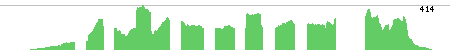

[figure not shown]

0.58386

rosettePlusRoot

95.37432

GSM798296: mRNASeq_WT_rep2  
[NCBI SRA](http://www.ncbi.nlm.nih.gov/Traces/sra/?run=SRR547531); [PubLink](http://www.ncbi.nlm.nih.gov/pubmed/23349984)  
More Details

Aerial part of 4-week-old plant

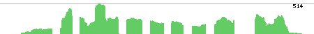

[figure not shown]

0.5711

rosettePlusRoot

125.79102

GSM994838; SRA: SRS360059  
[NCBI SRA](http://www.ncbi.nlm.nih.gov/Traces/sra/?run=SRR548277); [PubLink](http://www.ncbi.nlm.nih.gov/pubmed/23755095)  
More Details

Aerial part of 3-week-old soil-grown plant

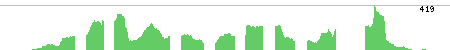

[figure not shown]

0.51599

rosettePlusRoot

61.20159

Seedling1,SRA: SRS419144  
[NCBI SRA](http://www.ncbi.nlm.nih.gov/Traces/sra/?run=SRR847503); [PubLink](http://www.ncbi.nlm.nih.gov/pubmed/24792048)  
More Details

Aerial part of 3-week-old soil-grown plant

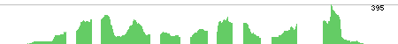

[figure not shown]

0.49929

rosettePlusRoot

59.12832

Seedling1,SRA: SRS419144  
[NCBI SRA](http://www.ncbi.nlm.nih.gov/Traces/sra/?run=SRR847504); [PubLink](http://www.ncbi.nlm.nih.gov/pubmed/24792048)  
More Details

Aerial part of 3-week-old soil-grown plant

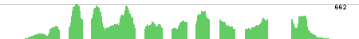

[figure not shown]

0.52444

rosettePlusRoot

154.56343

Seedling2, SRA: SRS419145  
[NCBI SRA](http://www.ncbi.nlm.nih.gov/Traces/sra/?run=SRR847505); [PubLink](http://www.ncbi.nlm.nih.gov/pubmed/24792048)  
More Details

Aerial part of 3-week-old soil-grown plant

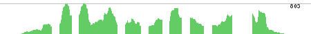

[figure not shown]

0.51595

rosettePlusRoot

186.01197

Seedling2, SRA: SRS419145  
[NCBI SRA](http://www.ncbi.nlm.nih.gov/Traces/sra/?run=SRR847506); [PubLink](http://www.ncbi.nlm.nih.gov/pubmed/24792048)  
More Details

Carpels collected manually from stage 8-13 flowers

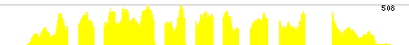

[figure not shown]

0.60687

[figure not shown]

FlowerParts

79.63302

Carpels collected manually from stage 8-13 flowers

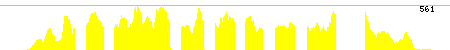

[figure not shown]

0.61

[figure not shown]

FlowerParts

92.41063

5do etiolated seedling

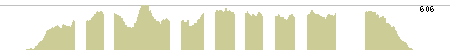

[figure not shown]

0.62408

etiolatedSeedling

107.5546

Etiolated wild type (Col-0) seedlings, GSM1252262, SRA: SRS494530  
[NCBI SRA](http://www.ncbi.nlm.nih.gov/Traces/sra/?run=SRR1019436); [PubLink](http://www.ncbi.nlm.nih.gov/pubmed/24867218)  
More Details

5do etiolated seedling

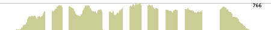

[figure not shown]

0.61998

etiolatedSeedling

124.79963

Etiolated wild type (Col-0) seedlings, GSM1252262, SRA: SRS494530  
[NCBI SRA](http://www.ncbi.nlm.nih.gov/Traces/sra/?run=SRR1019437); [PubLink](http://www.ncbi.nlm.nih.gov/pubmed/24867218)  
More Details

7do dark-grown seedling

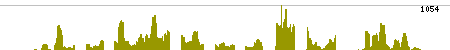

[figure not shown]

0.4263

[figure not shown]

10dayOldSeedling

76.04861

5do dark-grown seedling

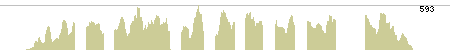

[figure not shown]

0.61422

etiolatedSeedling

149.19125

5do dark-grown seedling

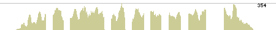

[figure not shown]

0.60864

etiolatedSeedling

149.59393

3do etiolated seedling

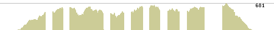

[figure not shown]

0.61708

etiolatedSeedling

99.28526

Col-0 air 3-day, SRA: SRS311825  
[NCBI SRA](http://www.ncbi.nlm.nih.gov/Traces/sra/?run=SRR493237); [PubLink](http://www.ncbi.nlm.nih.gov/pubmed/22936567)  
More Details

3do etiolated seedling

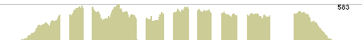

[figure not shown]

0.6226

etiolatedSeedling

89.42901

Col-0 air 3-day, SRA: SRS311825  
[NCBI SRA](http://www.ncbi.nlm.nih.gov/Traces/sra/?run=SRR493238); [PubLink](http://www.ncbi.nlm.nih.gov/pubmed/22936567)  
More Details

stage-12 floral buds from long-day grown plant

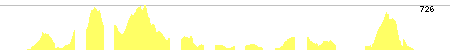

[figure not shown]

0.43086

Stage12Bud

69.58394

stage 12 floral bud, Col-0, GSM764079, SRA: SRS228279  
[NCBI SRA](http://www.ncbi.nlm.nih.gov/Traces/sra/?run=SRR314815); [PubLink](http://www.ncbi.nlm.nih.gov/pubmed/21874022)  
More Details

stage-12 floral bud

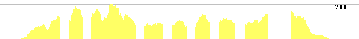

[figure not shown]

0.58826

Stage12Bud

103.63915

flowers, GSM1111913, SRA: SRS405938  
[NCBI SRA](http://www.ncbi.nlm.nih.gov/Traces/sra/?run=SRR800753); [PubLink](http://www.ncbi.nlm.nih.gov/pubmed/23749190)  
More Details

stage-12 floral bud

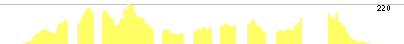

[figure not shown]

0.55702

Stage12Bud

108.59324

flowers, GSM1111914, SRA: SRS405939  
[NCBI SRA](http://www.ncbi.nlm.nih.gov/Traces/sra/?run=SRR800754); [PubLink](http://www.ncbi.nlm.nih.gov/pubmed/23749190)  
More Details

Leaf of 3-week-old long-day-grown plant

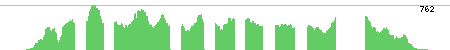

[figure not shown]

0.62551

leaf

94.65912

wildtype rep2 Columbia 0, SRA: SRS528136  
[NCBI SRA](http://www.ncbi.nlm.nih.gov/Traces/sra/?run=SRR1105822); [PubLink](http://www.ncbi.nlm.nih.gov/pubmed/24670657)  
More Details

Leaf of 3-week-old long-day-grown plant

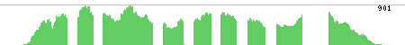

[figure not shown]

0.63355

leaf

172.75251

wildtype rep3 Columbia 0,SRA: SRS552303  
[NCBI SRA](http://www.ncbi.nlm.nih.gov/Traces/sra/?run=SRR1105823); [PubLink](http://www.ncbi.nlm.nih.gov/pubmed/24670657)  
More Details

Leaf of 20-day-old plant

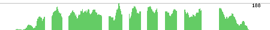

[figure not shown]

0.59221

leaf

59.3275

adult leaf tissue, GSM1321694, SRA: SRS552303  
[NCBI SRA](http://www.ncbi.nlm.nih.gov/Traces/sra/?run=SRR1159821); [PubLink](http://www.ncbi.nlm.nih.gov/pubmed/24799676)  
More Details

Leaf of 20-day-old plant

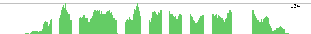

[figure not shown]

0.56513

leaf

83.65724

adult leaf tissue, GSM1321700, SRA: SRS552309  
[NCBI SRA](http://www.ncbi.nlm.nih.gov/Traces/sra/?run=SRR1159827); [PubLink](http://www.ncbi.nlm.nih.gov/pubmed/24799676)  
More Details

Leaf of 20-day-old plant

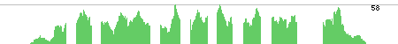

[figure not shown]

0.57488

leaf

59.16493

adult leaf tissue, GSM1321710, SRA: SRS552319  
[NCBI SRA](http://www.ncbi.nlm.nih.gov/Traces/sra/?run=SRR1159837); [PubLink](http://www.ncbi.nlm.nih.gov/pubmed/24799676)  
More Details

Leaf of 11-day-old plant

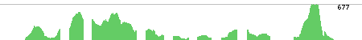

[figure not shown]

0.44516

leaf

60.56207

11-day-old seedling, Col-0, GSM764077, SRA: SRS228277  
[NCBI SRA](http://www.ncbi.nlm.nih.gov/Traces/sra/?run=SRR314813); [PubLink](http://www.ncbi.nlm.nih.gov/pubmed/21874022)  
More Details

Leaf of 6-week-old short-day-grown plant infiltrated with mock (virulent bacterium) and harvested 1h post-infiltration

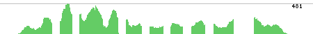

[figure not shown]

0.53702

leaf

50.38744

Leaf of 6-week-old short-day-grown plant infiltrated with mock (virulent bacterium) and harvested 1h post-infiltration

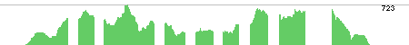

[figure not shown]

0.56509

leaf

65.50364

Leaf of 6-week-old short-day-grown plant infiltrated with mock (virulent bacterium) and harvested 6h post-infiltration

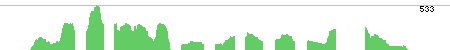

[figure not shown]

0.5043

leaf

24.42858

Leaf of 6-week-old short-day-grown plant infiltrated with mock (virulent bacterium) and harvested 6h post-infiltration

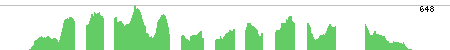

[figure not shown]

0.56022

leaf

39.57669

Leaf of 6-week-old short-day-grown plant infiltrated with mock (virulent bacterium) and harvested 12h post-infiltration

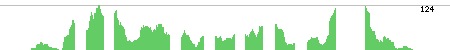

[figure not shown]

0.47862

leaf

28.21759

Leaves of six week-old Arabidopsis Columbia (Col-0) wild type, SRA: SRS293921  
[NCBI SRA](http://www.ncbi.nlm.nih.gov/Traces/sra/?run=SRR446039); [PubLink](http://www.ncbi.nlm.nih.gov/bioproject/PRJNA173828)  
More Details

Leaf of 6-week-old short-day-grown plant infiltrated with mock (virulent bacterium) and harvested 12h post-infiltration

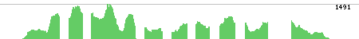

[figure not shown]

0.54033

leaf

73.66534

Leaves of six week-old Arabidopsis Columbia (Col-0) wild type, SRA: SSRS293922  
[NCBI SRA](http://www.ncbi.nlm.nih.gov/Traces/sra/?run=SRR446040); [PubLink](http://www.ncbi.nlm.nih.gov/bioproject/PRJNA173828)  
More Details

Non-dividing tissues (oldest 4-6 leaves) of 4-week-old short-day-grown plant

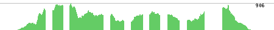

[figure not shown]

0.57495

leaf

116.27914

Oldest 4 to 6 leaves, GSM897684;, SRA: SRS301779  
[NCBI SRA](http://www.ncbi.nlm.nih.gov/Traces/sra/?run=SRR446484); [PubLink](http://www.ncbi.nlm.nih.gov/pubmed/22570629)  
More Details

Dividing tissues (meristem and younger leaves) of 4-week-old short-day-grown plant

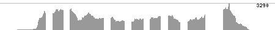

[figure not shown]

0.54407

ShootApexInflorescense

300.78349

Meristem and younger leaves, GSM897685;, SRA: SRS301780  
[NCBI SRA](http://www.ncbi.nlm.nih.gov/Traces/sra/?run=SRR446485); [PubLink](http://www.ncbi.nlm.nih.gov/pubmed/22570629)  
More Details

Non-dividing tissues (oldest 4-6 leaves) of 4-week-old short-day-grown plant

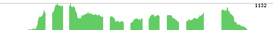

[figure not shown]

0.53332

leaf

126.84502

Oldest 4 to 6 leaves, GSM897686, SRA: SRS301781  
[NCBI SRA](http://www.ncbi.nlm.nih.gov/Traces/sra/?run=SRR446486); [PubLink](http://www.ncbi.nlm.nih.gov/pubmed/22570629)  
More Details

Dividing tissues (meristem and younger leaves) of 4-week-old short-day-grown plant

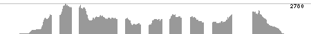

[figure not shown]

0.56406

ShootApexInflorescense

287.68791

Meristem and younger leaves, GSM897687, SRA: SRS301782  
[NCBI SRA](http://www.ncbi.nlm.nih.gov/Traces/sra/?run=SRR446487); [PubLink](http://www.ncbi.nlm.nih.gov/pubmed/22570629)  
More Details

Leaf of 2-week-old plant

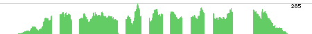

[figure not shown]

0.60361

leaf

82.07364

leaf tissue, wild type, mRNA, GSM925644, SRA: SRS311724  
[NCBI SRA](http://www.ncbi.nlm.nih.gov/Traces/sra/?run=SRR493036); [PubLink](http://www.ncbi.nlm.nih.gov/pubmed/22555433)  
More Details

Leaf of 5-week-old short-day-grown plant

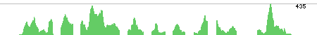

[figure not shown]

0.48316

leaf

59.54821

Col-0 Untreated Adult Plants, SRA: SRS311683  
[NCBI SRA](http://www.ncbi.nlm.nih.gov/Traces/sra/?run=SRR493097); [PubLink](http://bar.utoronto.ca/~dev/eFP-Seq_Browser/undefined)  
More Details

Leaf of 5-week-old short-day-grown plant

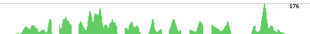

[figure not shown]

0.48081

leaf

63.0716

Col-0 Untreated Adult Plants, SRA: SRS311683  
[NCBI SRA](http://www.ncbi.nlm.nih.gov/Traces/sra/?run=SRR493098); [PubLink](http://bar.utoronto.ca/~dev/eFP-Seq_Browser/undefined)  
More Details

Leaf of 5-week-old short-day-grown plant

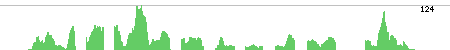

[figure not shown]

0.45956

leaf

60.90777

Col-0 Untreated Adult Plants, SRA: SRS311683  
[NCBI SRA](http://www.ncbi.nlm.nih.gov/Traces/sra/?run=SRR493101); [PubLink](http://bar.utoronto.ca/~dev/eFP-Seq_Browser/undefined)  
More Details

Leaf of 4-week-old long-day-grown plant

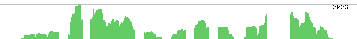

[figure not shown]

0.5164

leaf

189.02622

WT 4wks leaves RNA-seq, GSM1088166, SRA: SRS398009  
[NCBI SRA](http://www.ncbi.nlm.nih.gov/Traces/sra/?run=SRR764885); [PubLink](http://bar.utoronto.ca/~dev/eFP-Seq_Browser/undefined)  
More Details

Leaf of 3-week-old plant

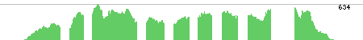

[figure not shown]

0.60278

leaf

72.65297

Col-0 WT1, SRA: SRS454429  
[NCBI SRA](http://www.ncbi.nlm.nih.gov/Traces/sra/?run=SRR924656); [PubLink](http://www.ncbi.nlm.nih.gov/pubmed/24657166)  
More Details

Leaf of 2-week-old long-day-grown plant

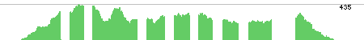

[figure not shown]

0.60211

leaf

67.55782

leaves of wild type Arabidopsis, GSM1185649, SRA: SRS457504  
[NCBI SRA](http://www.ncbi.nlm.nih.gov/Traces/sra/?run=SRR934391); [PubLink](http://bar.utoronto.ca/~dev/eFP-Seq_Browser/undefined)  
More Details

Leaf of 3-week-old long-day-grown plant

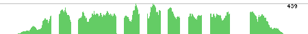

[figure not shown]

0.59511

leaf

151.3062

3 week leaf tissue, GSM1193626, SRA: SRS463362  
[NCBI SRA](http://www.ncbi.nlm.nih.gov/Traces/sra/?run=SRR942022); [PubLink](http://www.ncbi.nlm.nih.gov/pubmed/24244201)  
More Details

4-day-old 24h-light-grown seedling

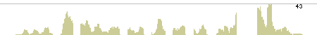

[figure not shown]

0.44006

etiolatedSeedling

17.1127

whole seedling, WT, GSM613465, SRA: SRS118358  
[NCBI SRA](http://www.ncbi.nlm.nih.gov/Traces/sra/?run=SRR070570); [PubLink](http://www.ncbi.nlm.nih.gov/pubmed/21265889)  
More Details

4-day-old 24h-light-grown seedling

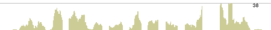

[figure not shown]

0.48585

etiolatedSeedling

19.37608

whole seedling, WT, GSM613465, SRA: SRS118358  
[NCBI SRA](http://www.ncbi.nlm.nih.gov/Traces/sra/?run=SRR070571); [PubLink](http://www.ncbi.nlm.nih.gov/pubmed/21265889)  
More Details

10-day-old long-day plate-grown seedling

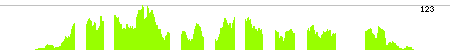

[figure not shown]

0.5249

[figure not shown]

10dayOldSeedling

69.3819

10d-old seedling, GSM1239087, SRA: SRS487056  
[NCBI SRA](http://www.ncbi.nlm.nih.gov/Traces/sra/?run=SRR1001909); [PubLink](http://www.ncbi.nlm.nih.gov/pubmed/24505057)  
More Details

10-day-old long-day plate-grown seedling

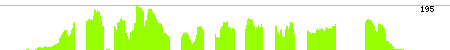

[figure not shown]

0.52512

[figure not shown]

10dayOldSeedling

118.70015

10d-old seedling, GSM1239088, SRA: SRS487057  
[NCBI SRA](http://www.ncbi.nlm.nih.gov/Traces/sra/?run=SRR1001910); [PubLink](http://www.ncbi.nlm.nih.gov/pubmed/24505057)  
More Details

15-d-old long-day plate-grown

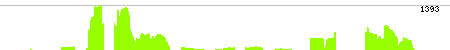

[figure not shown]

0.36236

[figure not shown]

15dayOldSeedling

46.15761

14-d-old entire seedlings, GSM1252086, SRA: SRS494447  
[NCBI SRA](http://www.ncbi.nlm.nih.gov/Traces/sra/?run=SRR1019221); [PubLink](http://www.ncbi.nlm.nih.gov/pubmed/24248388)  
More Details

7-day-old plate-grown long-day seedlings

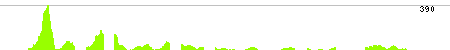

[figure not shown]

0.2895

[figure not shown]

10dayOldSeedling

33.84922

Seedling, GSM798295, SRA: SRS261467  
[NCBI SRA](http://www.ncbi.nlm.nih.gov/Traces/sra/?run=SRR345561); [PubLink](http://www.ncbi.nlm.nih.gov/pubmed/22942380)  
More Details

7-day-old plate-grown long-day seedlings

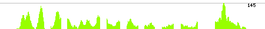

[figure not shown]

0.45149

[figure not shown]

10dayOldSeedling

37.44169

Seedling, GSM798296, SRA: SRS261468  
[NCBI SRA](http://www.ncbi.nlm.nih.gov/Traces/sra/?run=SRR345562); [PubLink](http://www.ncbi.nlm.nih.gov/pubmed/22942380)  
More Details

7-day-old plate-grown long-day seedlings

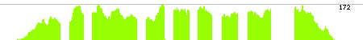

[figure not shown]

0.63718

[figure not shown]

10dayOldSeedling

47.58949

two week old seedling, GSM800621, SRA: SRS265285  
[NCBI SRA](http://www.ncbi.nlm.nih.gov/Traces/sra/?run=SRR346552); [PubLink](http://www.ncbi.nlm.nih.gov/pubmed/22293517)  
More Details

7-day-old plate-grown long-day seedlings

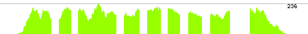

[figure not shown]

0.64805

[figure not shown]

10dayOldSeedling

51.3337

two week old seedling, GSM800622, SRA: SRS265286  
[NCBI SRA](http://www.ncbi.nlm.nih.gov/Traces/sra/?run=SRR346553); [PubLink](http://www.ncbi.nlm.nih.gov/pubmed/22293517)  
More Details

10-day-old long-day plate-grown seedling

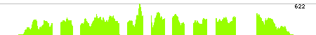

[figure not shown]

0.62285

[figure not shown]

10dayOldSeedling

69.04728

10 day seedlings, GSM856058, SRA: SRS284668  
[NCBI SRA](http://www.ncbi.nlm.nih.gov/Traces/sra/?run=SRR394082); [PubLink](http://www.ncbi.nlm.nih.gov/pubmed/22431625)  
More Details

2-week-old long-day seedling

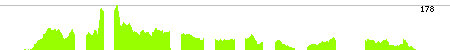

[figure not shown]

0.52669

[figure not shown]

15dayOldSeedling

22.80443

2-3 week seedlings, GSM941528, SRA: SRS344127  
[NCBI SRA](http://www.ncbi.nlm.nih.gov/Traces/sra/?run=SRR504179); [PubLink](http://www.ncbi.nlm.nih.gov/pubmed/23246435)  
More Details

2-week-old long-day seedling

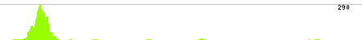

[figure not shown]

0.1773

[figure not shown]

15dayOldSeedling

12.81561

2-3 week seedlings, GSM941529, SRA: SRS344128  
[NCBI SRA](http://www.ncbi.nlm.nih.gov/Traces/sra/?run=SRR504180); [PubLink](http://www.ncbi.nlm.nih.gov/pubmed/23246435)  
More Details

2-week-old long-day seedling

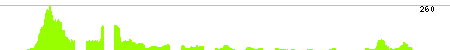

[figure not shown]

0.3258

[figure not shown]

15dayOldSeedling

13.96625

2-3 week seedlings, GSM941530, SRA: SRS344129  
[NCBI SRA](http://www.ncbi.nlm.nih.gov/Traces/sra/?run=SRR504181); [PubLink](http://www.ncbi.nlm.nih.gov/pubmed/23246435)  
More Details

7-day-old plate-grown, long-day-grown seedling

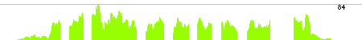

[figure not shown]

0.54592

[figure not shown]

10dayOldSeedling

101.93865

Arabidopsis thaliana seedlings, SRA: SRS346091  
[NCBI SRA](http://www.ncbi.nlm.nih.gov/Traces/sra/?run=SRR515073); [PubLink](http://bar.utoronto.ca/~dev/eFP-Seq_Browser/undefined)  
More Details

7-day-old plate-grown, long-day-grown seedling

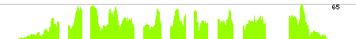

[figure not shown]

0.55839

[figure not shown]

10dayOldSeedling

108.38451

Arabidopsis thaliana seedlings, SRA: SRS346091  
[NCBI SRA](http://www.ncbi.nlm.nih.gov/Traces/sra/?run=SRR515074); [PubLink](http://bar.utoronto.ca/~dev/eFP-Seq_Browser/undefined)  
More Details